# The emergence of lexical categories from iterated vocal imitation

Pierce Edmiston

# Seed selection

We started with 6 sounds in each of 6 categories and reduced that number to 4 sounds in each of 4 categories through two “odd one out” norming experiments.

# Collecting imitations

## Methods

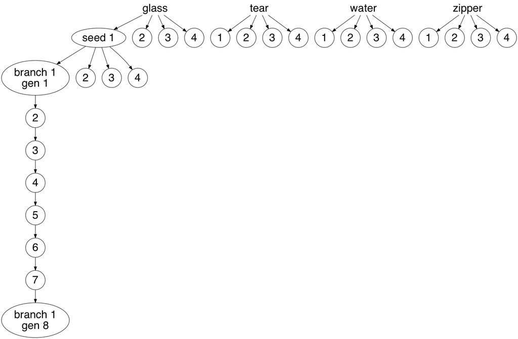

## Results

1. From generation to generation
2. Across different branches in the same generation

# Matching imitations to seeds

## Methods

### Question types

Each imitation is matched in three different “guess the seed” conditions:

1. Category match (true seed)
2. Category match
3. Specific match

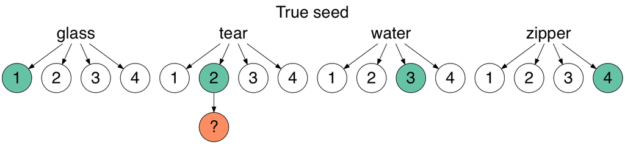

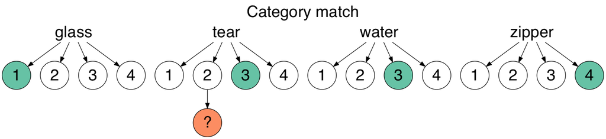

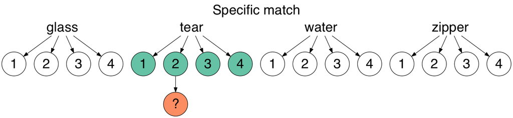

### Number of responses per question

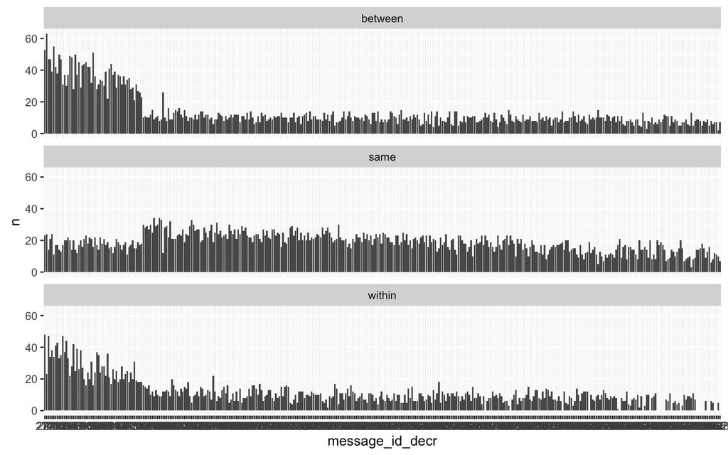

## Results

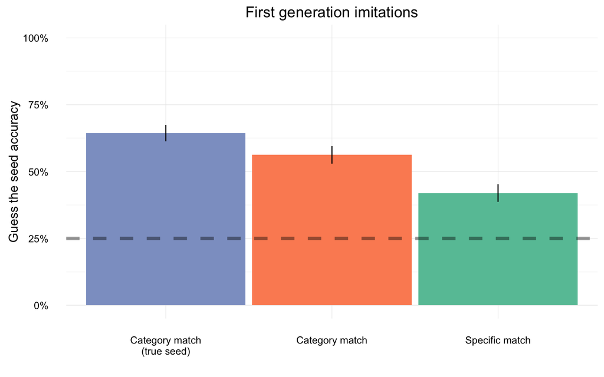

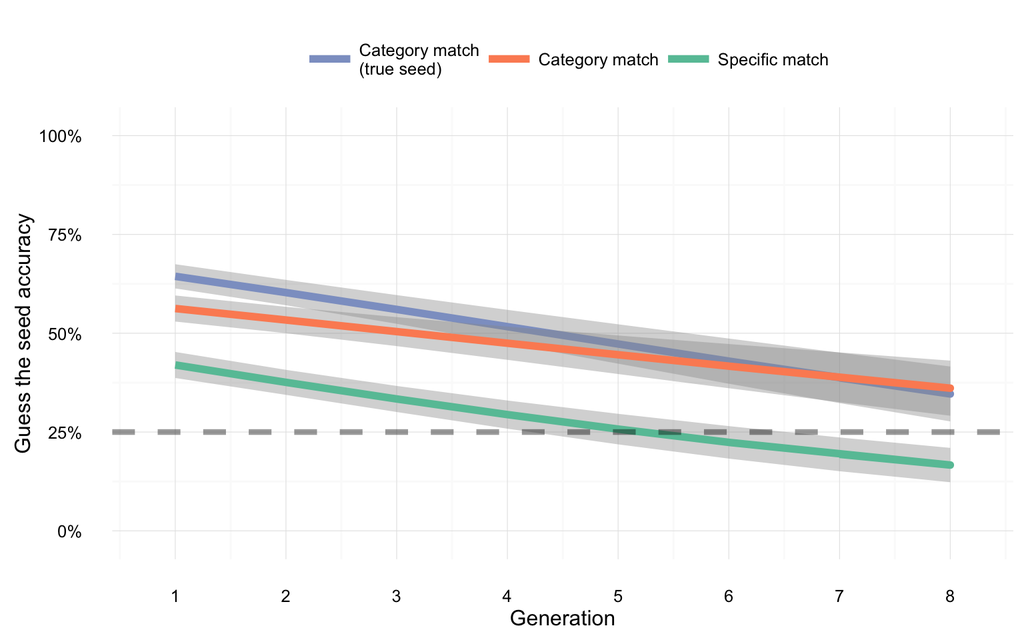

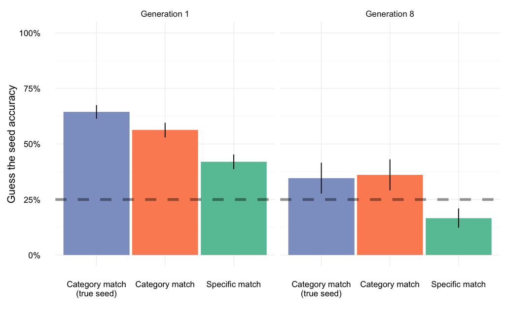

# Transcriptions of imitations

## Methods

### Selected sounds

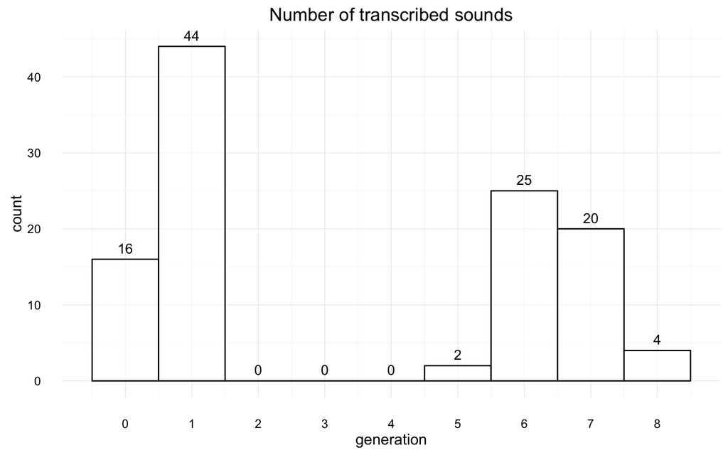

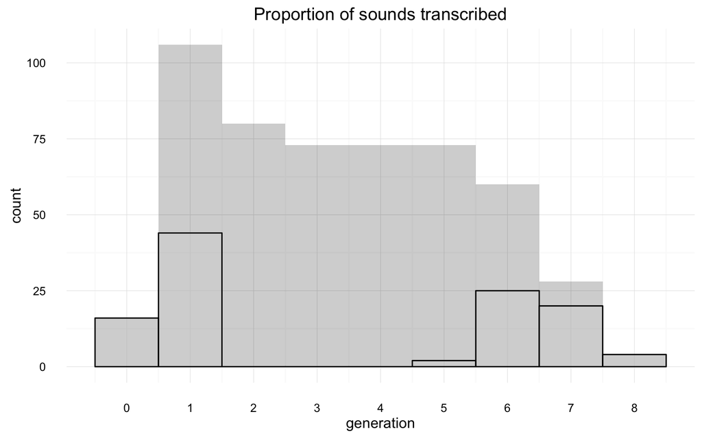

### Number of transcriptions for each sound

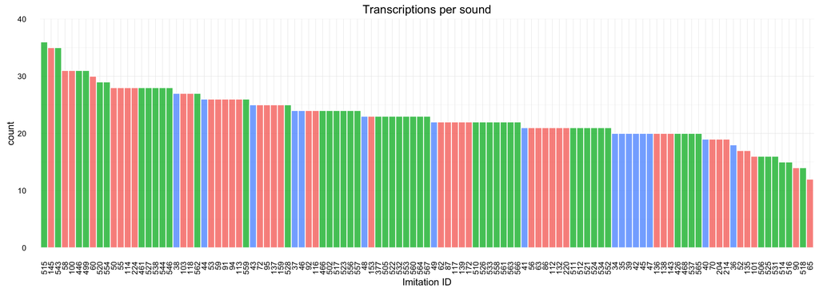

## Results

### Exact agreement

Transcription agreement for each sound, controlling for case only. Messages with no agreement among transcriptions had all unique transcriptions.

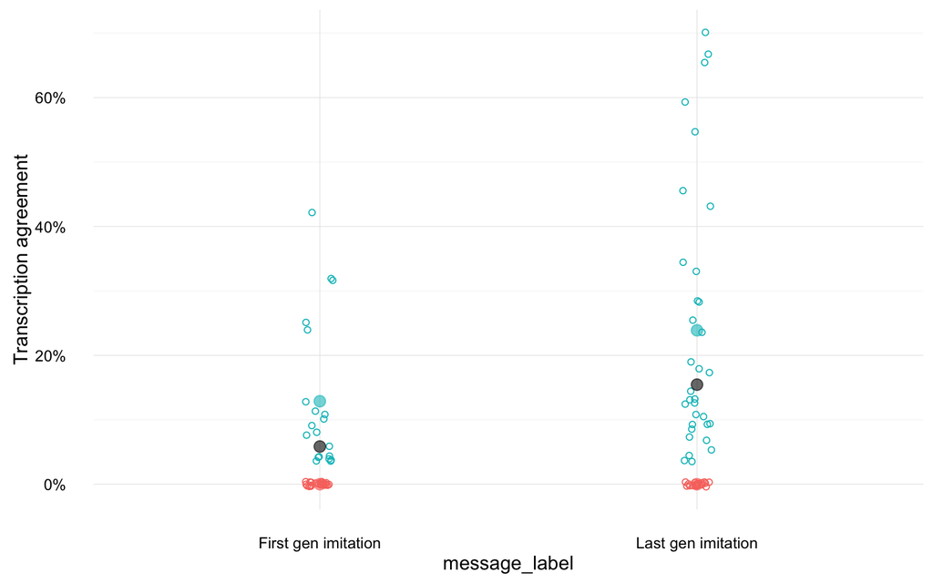

### Pattern distance

Transcription agreement by average pattern match distance to the single most frequent transcription. For messages with no duplicate transcriptions, distances are calculated relative to a randomly selected transcription (and therefore the distance metric is inappropriate).

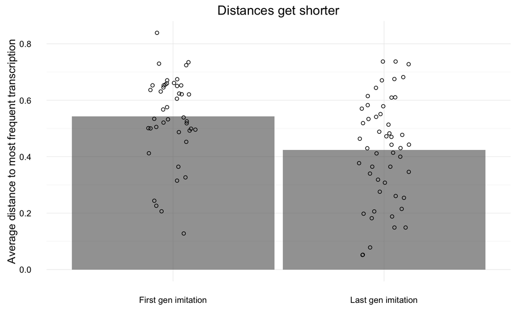

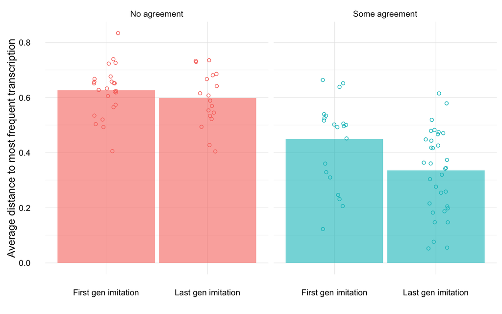

### Length of pattern

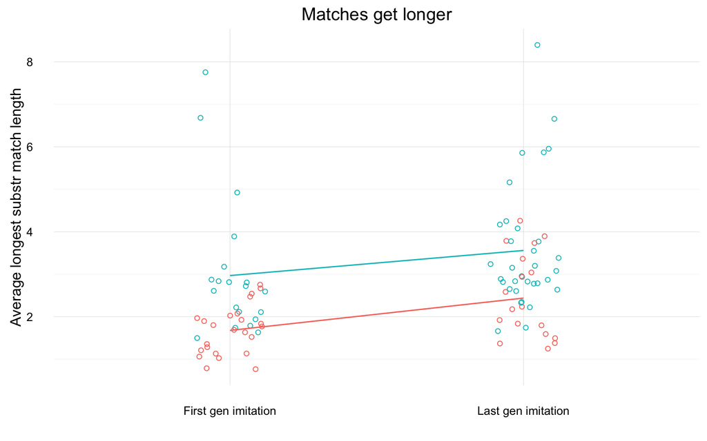

### Phonological similarity

# Matching transcriptions to seeds

## Methods

### Subjects

[output not shown]

Subjects were excluded if they failed the catch trial, which indicated that they should select the third option.

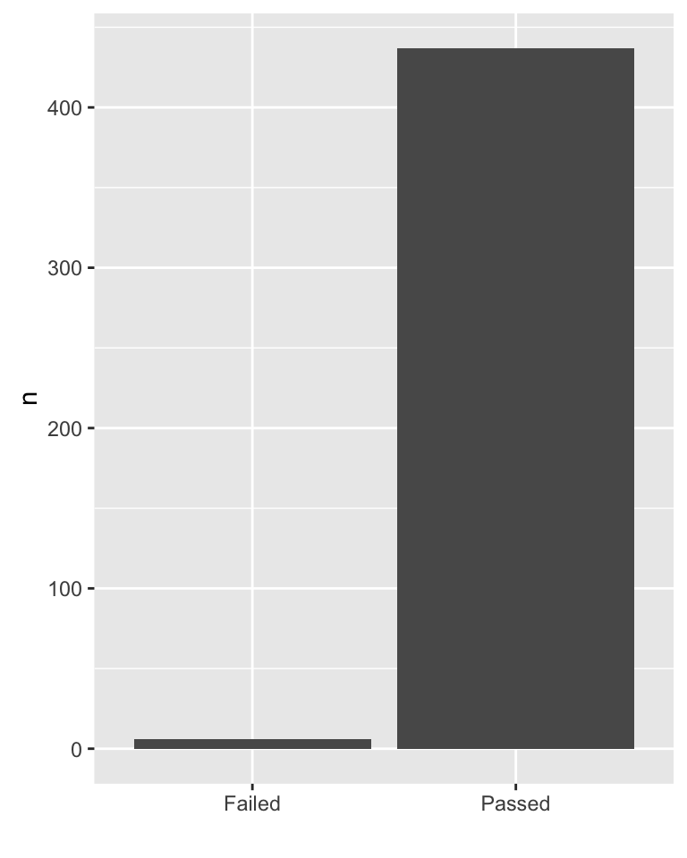

### Number of responses

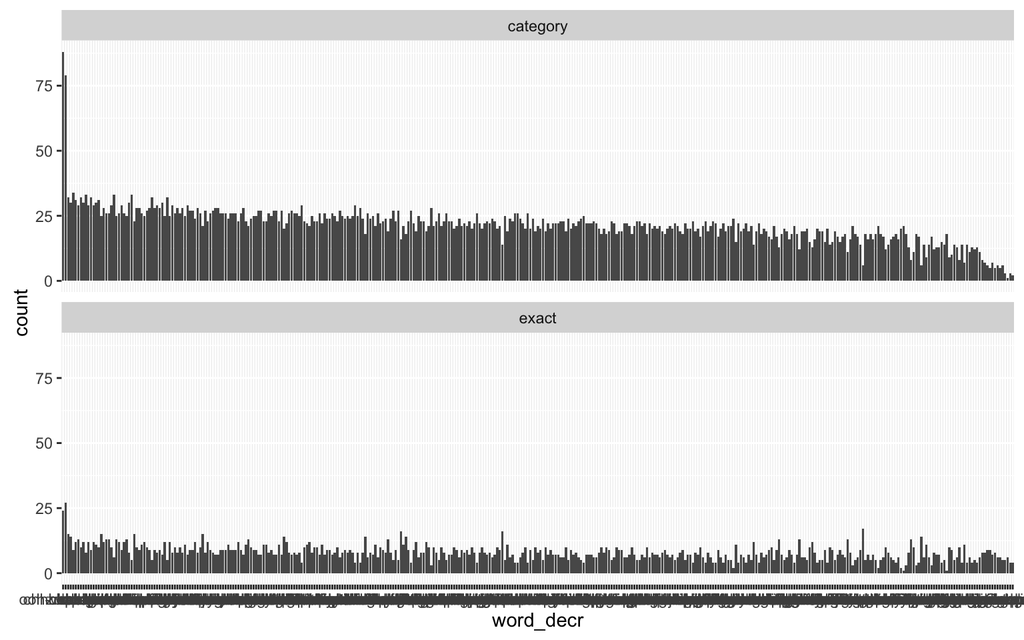

## Results

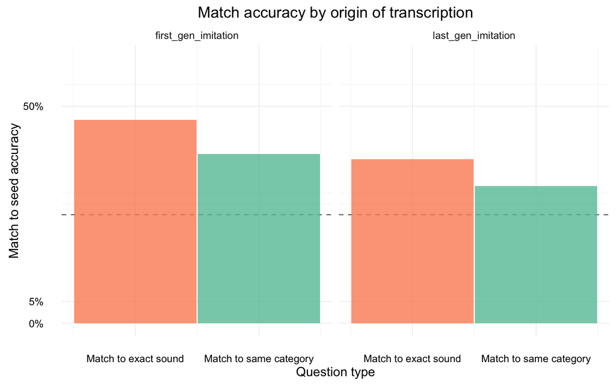

```r
acc_mod <- glmer(is_correct ~ question_c * message_c + (question_c * message_c|subj_id),
                 family = binomial, data = transcription_matches)
```

| term | estimate | std.error | statistic | p.value |
| --- | --- | --- | --- | --- |
| (Intercept) | -0.4756751 | 0.0267823 | -17.7607806 | 0.0000000 |
| question_c | -0.2920099 | 0.0491335 | -5.9431951 | 0.0000000 |
| message_c | -0.3297712 | 0.0537481 | -6.1354984 | 0.0000000 |
| question_c:message_c | 0.0475336 | 0.1002399 | 0.4741983 | 0.6353585 |

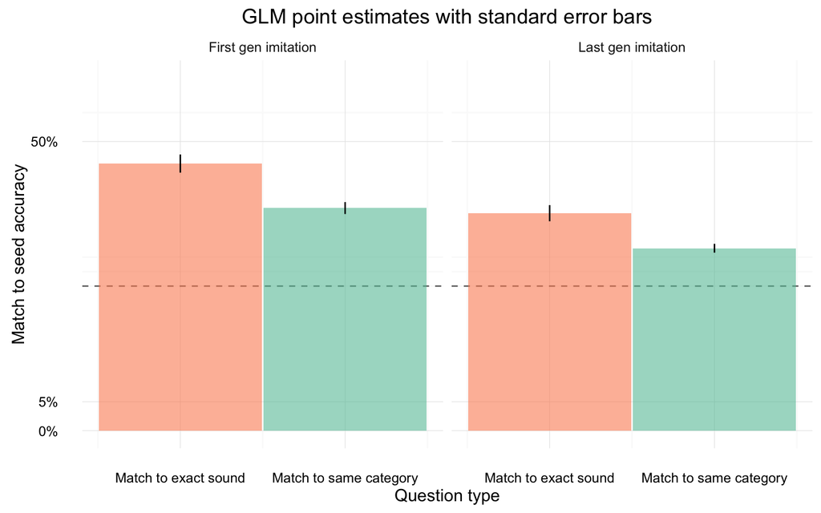

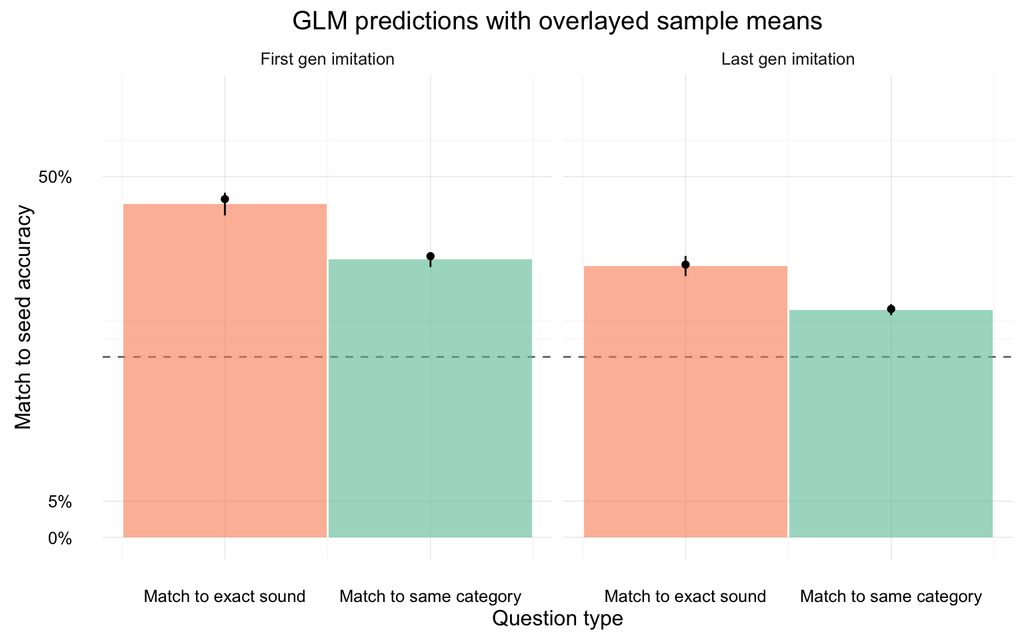

### Agreement as a predictor of matching accuracy

Do the imitations where there is a lot of agreement in the transcriptions have higher matching accuracy?